# Emergence, Self-organization, Complexity and Homostasis

G. Santamaria-Bonfil

# 1 Libraries required

First, the required libraries must be loaded. These are standard `R` packages such as `data.table`, `dplyr`, `ggplot2`, `reshape2`, and so on.

# 2 Entropy-based Emergence, Self-Organization, and Complexity measures

To fully grasp the idea behind the *ESC* measures, lets show them with an example. Consider a phenomenon (such as a coin) that can be described by the Binomial distribution, that is defined as follows:

$$Pr(k;n,p) = Pr(X = H) = {{n}\choose{k}}
\cdot p^kq^{n-k},$$
where $k$ successes occur with probability $p^k$ and $n − k$ failures occur with probability $q = (1 − p)^{n − k}$; the $k$ successes can occur anywhere among the $n$ trials, and there are ${{n}\choose{k}}$ different ways of distributing $k$ successes in a sequence of $n$ trials.

## 2.1 E = 1

Suppose a non-biased coin, where the probability of getting a HEAD (H) or a TAIL (T) is the same, i.e. Pr(H=T)=0.5. In this case, the distribution that describes the coin behavior corresponds to a uniform distribution. Consequently, the emergence of the system is maximal, with zero self-organization and complexity.

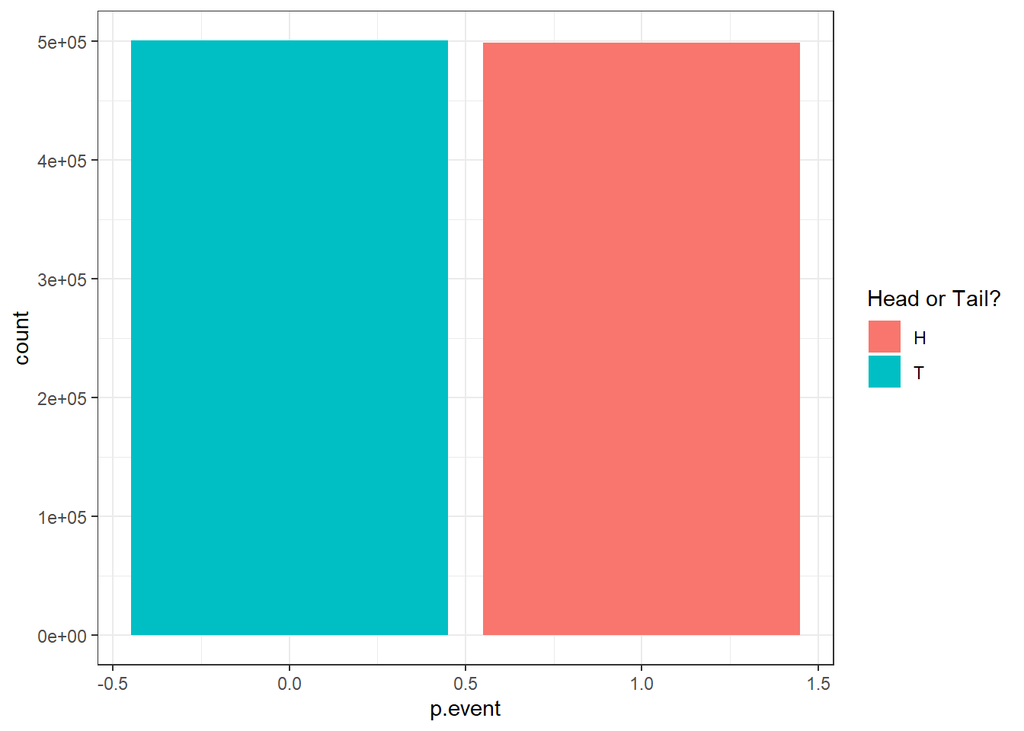

```r
set.seed(123)
tmp.dist <- rbinom(n = 1000000,size = 1,prob = 0.5)
tmp.dist.df <- data.frame(p.event = tmp.dist)
tmp.dist.df$Event <- ifelse(tmp.dist.df$p.event ==1, 'blue','red')
ggplot(tmp.dist.df, aes(x=p.event, fill=Event))+geom_bar()+
  scale_fill_discrete(name = "Head or Tail?", labels = c("H", "T"))+theme_bw()
```

```r
complexity.discrete(tmp.dist,no_states = 2)
```

| E | S | C | Entrop |
| --- | --- | --- | --- |
| 0.9999981 | 1.921255e-06 | 7.685006e-06 | 0.9999981 |

## 2.2 S = 1

Suppose a biased coin, where the probability of getting a HEAD (H) is Pr(H)=1 and for TAIL (T) Pr(T) = 1-Pr(H)=0. In this case, the distribution that describes the coin behavior corresponds to a Dirac delta distribution. Consequently, the self-organization of the system is maximal, with zero emergence and complexity.

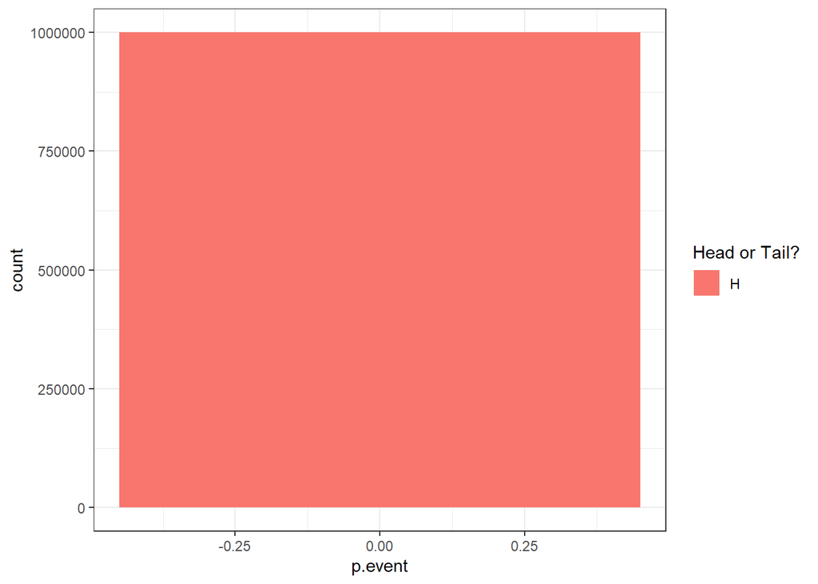

```r
set.seed(123)
tmp.dist <- rbinom(n = 1000000,size = 1,prob = 0)
tmp.dist.df <- data.frame(p.event = tmp.dist)
tmp.dist.df$Event <- ifelse(tmp.dist.df$p.event ==1, 'blue','red')
ggplot(tmp.dist.df, aes(x=p.event, fill=Event))+geom_bar()+
  scale_fill_discrete(name = "Head or Tail?", labels = c("H", "T"))+theme_bw()
```

```r
complexity.discrete(tmp.dist,no_states = 2)
```

| E | S | C | Entrop |
| --- | --- | --- | --- |
| 0 | 1 | 0 | 0 |

## 2.3 A balance between E and S: C

Now suppose a biased coin which is being manipulated such that, it is getting biased from displaying always $H$ (i.e. $p(H)=1; p(T)=0$) towards displaying always $T$ (i.e. $p(H)=0; p(T)=1$) by increments of $0.001$ (e.g. $p(H)=0.999; p(T)=0.001$, $p(H)=0.998; p(T)=0.002$, $p(H)=0.997; p(T)=0.003$, and so on). The resulting $E, S, C$ measures for such distributions will be depicted by the following figure.

In this sense the complexity is maximal, i.e. $C=1$, when one of the states (either H or T) has a higher probability of occurrence, still the probability of occurrence for the opposite event is not zero.

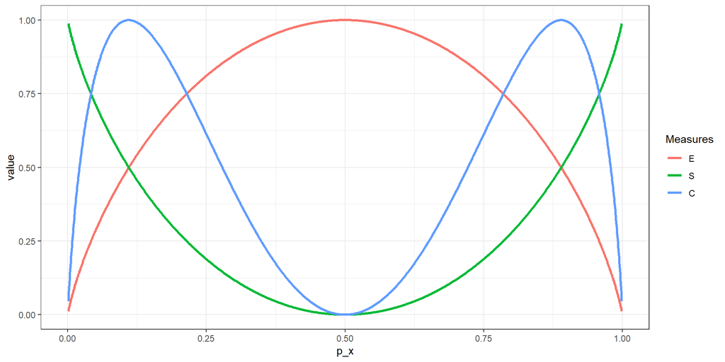

```r
no_states <- 2
p.event   <- seq(0.001,0.999,by=0.001)
kConst    <- 1/log2(no_states)

esc.binDist           <- data.frame(p_x = p.event,
                                    p_y=1-p.event)

for(i in 1:dim(esc.binDist)[1])
{
  entrop <- Entropy(esc.binDist[i,],nonNAidxes = 1:2)

  emergence         <- kConst*entrop
  selfOrganization  <- 1 - emergence
  complexity        <- 4 * emergence * selfOrganization

  esc.binDist$E[i] <- emergence
  esc.binDist$S[i] <- selfOrganization
  esc.binDist$C[i] <- complexity
}

esc.binDist.mlt <- melt(esc.binDist,id.vars=c('p_x','p_y'))


ggplot(esc.binDist.mlt, aes(x=p_x, y = value,color = variable))+
  geom_line(size = 1.2)+theme_bw()+labs(color = 'Measures')
```

## 2.4 ESC for continuous variables

When estimating the ESC of continuous variables, a simple approach is employed i.e., discretizing the variable values into $b$ bins of equal size. These **bins** correspond to the number of states a system can display. If the number of states a system can display is known beforehand, set $b$ equal to such value, otherwise as a rule of thumb we recommend to set it as $b=10$. Further, we can analyze multiple scales of the same system by increasing or reducing $b$. The parameter $b$ is used to normalize $E$ between $[0,1]$ by multiplying $H(P)\cdot K$, where
$$K=\frac{1}{\log_2 b}.$$
It is worth to notice that $\log_2 b$ corresponds to the maximum entropy a system with $b$ states can display, which is the uniform probability distribution function (i.e., $p_1=p_2=\ldots p_b$). Thus, we can represent $E$ such that
$$E = \frac{H(P)}{H(U)},$$
where $H(U)$ corresponds to the entropy of the uniform probability distribution function; $b$ bins are used to discretize $P$ and $U$ values (for $U$ we plug $b$ directly into $\log_2 b$).

```r
set.seed(123)
fff <- runif(1000, min = 0, max = 1)
complexity.discrete(pmfSample = fff,no_states = 100)
```

| E | S | C | Entrop |
| --- | --- | --- | --- |
| 0.9924552 | 0.007544805 | 0.02995152 | 6.59373 |

```r
set.seed(123)
fff <- runif(100000, min = 0, max = 100)
print(complexity.discrete(pmfSample = fff,no_states = 100))
```

```
##           E            S            C   Entrop
## 1 0.9999075 9.247391e-05 0.0003698614 6.643242
```

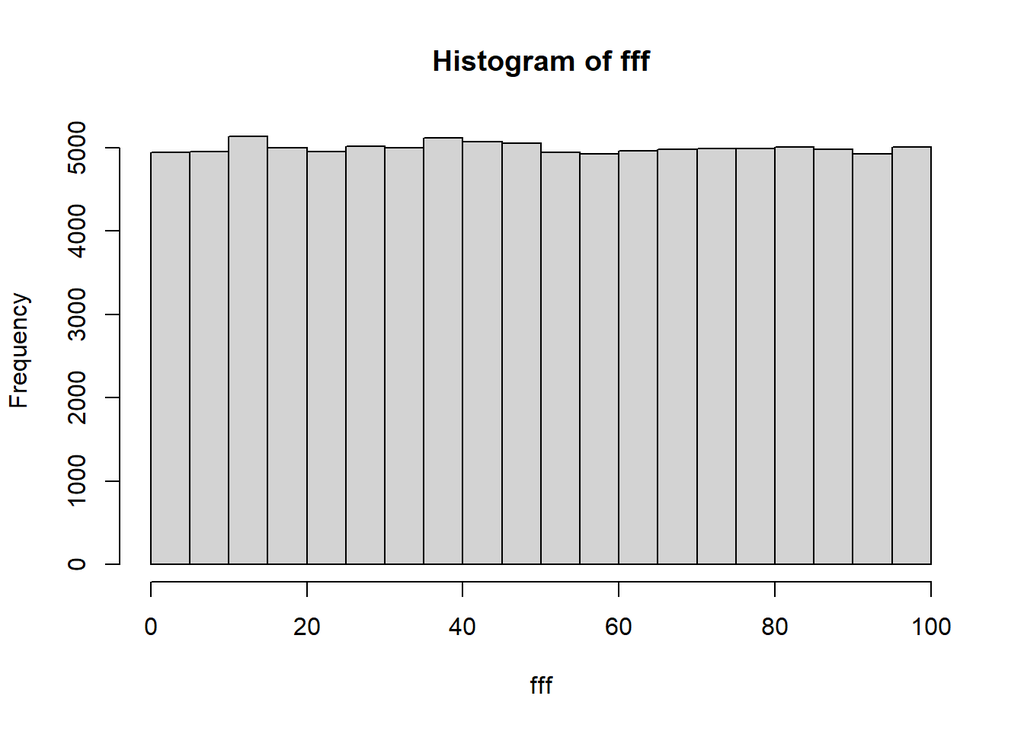

```r
hist(fff,breaks = 30)
```

```r
set.seed(123)
fff <- rnorm(100000, mean = 0, sd = 1)
print(complexity.discrete(pmfSample = fff,no_states = 10000))
```

```
##           E          S         C   Entrop
## 1 0.9176946 0.08230537 0.3021248 12.19406
```

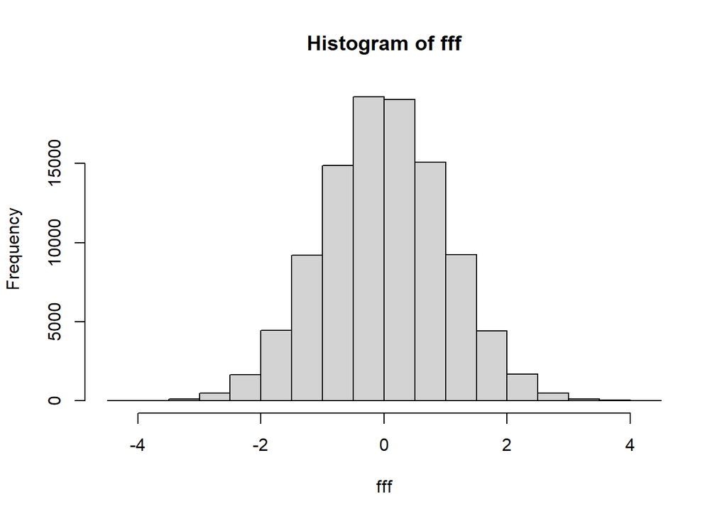

```r
hist(fff,breaks = 30)
```

# 3 Homeostasis

## 3.1 What is Homeostasis (H)?

Homeostasis (H) from the Greek hómoios (similar) and stasis (standing still). In accordance to Ashby, H implicates an adaptive reaction to maintain “essential variables” within a range of *viability* (Fernández, Maldonado, and Gershenson 2014).

H measures how all variables (two or more) of a system change simultaneously in time. For instance consider the following table. Observe that the `state of the system´ is defined by the rows of the table.

A dynamic system with 3 variables

|  | X | Y | Z |
| --- | --- | --- | --- |
| t_1 | x_1 | y_1 | z_1 |
| t_2 | x_2 | y_2 | z_2 |
| t_3 | x_3 | y_3 | z_3 |

First, lets define a system state as the vector $A_t=[x_t,\ y_t,\ldots,\ z_t]$, where its dimension is of size $|A_t|=n$. In order that $H$, measures the “average rate of change” between states, it is required that $H: \Sigma \times \Sigma \rightarrow \mathbb{R}$ satisfies the following:

1. $H\in [0,1]$
2. $H=1$ iff $A_t=A_{t+1}$, thus, no change in time.
3. $H=0$ iff $A_t\neq A_{t+1}$, thus, all variables changed in time.

## 3.2 Hamming distance as a proxy of H

As originally coined (Gershenson and Fernández 2012; Fernández, Maldonado, and Gershenson 2014), H is measured using the **Hamming distance**. The reason for this is that, the Hamming distance $d$, measures the percentage of different symbols in two strings $A_t$ and $A_{t+1}$. In the case of binary strings, the XOR $\oplus$ function can be employed to estimate $d$ such as

$$d(A_t,A_{t+1})=\sum_{i=1,\ldots,n}
a_t^i\oplus a_{t+1}^i$$

### 3.2.1 Questions about the Hamming distance for measuring Homeostasis

#### 3.2.1.1 For Real values

Previous works do not mention what to do when analyzing a system states where each of its features takes continuous values. In accordance to [Wikipedia](https://en.wikipedia.org/wiki/Hamming_distance) ” One can also view a binary string of length n as a vector in ${\displaystyle \mathbb{R}^{n}}$ by treating each symbol in the string as a real coordinate; with this embedding, the strings form the vertices of an $n$-dimensional hypercube, and the Hamming distance of the strings is equivalent to the Manhattan distance between the vertices”. Thus the questions are:

1. For the estimation of H when $a_t^i\in A_t$ such that $a_t^i\in \mathbb{R}$, should we employ the **Manhattan distance**?

$$d(A_t,A_{t+1})= \lVert A_t-A_{t+1}
\rVert= \sum_{i=1}^n \mid a_t^i - a_{t+1}^i\mid$$

2. If this is the case, how shall we normalize the **Manhattan distance**? I found [this](https://www.pbarrett.net/techpapers/euclid.pdf), which is a similarity measure based on the Euclidean distance. It normalizes the Euclidean distance, by dividing each difference by the maximum difference for that variable. But I am not sure how to proceed here.

## 3.3 Normalized Hamming distance.

Its normalization bounds the Hamming distance to the interval $[0, 1]$:

$$\bar{d}(A_t,A_{t+1})=\frac{\sum_{i=1,\ldots,n}
a_t^i\oplus a_{t+1}^i}{n}$$

For the Boolean case, $\bar{d}=0$ when $A_t=A_{t+1}$, $\bar{d}=1$ when $A_t\neq A_{t+1}$, and $\bar{d}\approx0.5$ when $A_t,\ A_{t+1}$ values are not correlated at all.

## 3.4 homeostasis and Homeostasis

The homeostasis ($h$) corresponds to the “rate of change” between two specific states e.g., $A_{t=1}$ and $A_{t=2}$, whereas $H$ corresponds to the **average $h$**. $h$ can be defined as follows,

$$h(A_t,A_{t+1})=1-\bar{d}(A_t,A_{t+1}).$$

Given this definition of $h$, $H$ is defined as follows

$$H= \frac{1}{m-1} \sum_{t=0}^{m-1}
h(A_t,A_{t+1}),$$
where $m$ is the total number of time steps being evaluated. $H$ is simply the average of different $h$ from $t = 0$ to $t = m − 1$; it is also unitless.

## 3.5 Questions about H for multiple scales

### 3.5.1 For binary strings.

When $H$ is measured at higher scales, it can capture periodic dynamics. For example, let us have a system with $n = 2$ variables and a cycle of period 2: $11 \rightarrow 00 \rightarrow 11$. $H$ for base 2 will be minimal, since every time step all variables change, i.e. ones turn into zeros or zeros turn into ones. However, if we measure $H$ in base 4, then we will be actually comparing **pairs of states**, since *to make one time step in base 4 we take two binary time steps* (Gershenson and Fernández 2012; Fernández, Maldonado, and Gershenson 2014). Thus, in base 4 the attractor becomes $22 \rightarrow 22$, and H = 1.

1. From the example and explanation above, how is the base b related to the *window of measurements* (b_order)? In the aforementioned example (a system with 2 variables $X_1$ and $X_2$ which follows $11 \rightarrow 00 \rightarrow 11\rightarrow\ldots$) **if we only change the b_order from 1 to 2 without modifying the base of the measurements**, the string will change to $1010 \rightarrow 1010$ (instead of $22 \rightarrow 22$). If we change or not the base of the measurements will have no difference in the resulting Hamming distance. In fact, due to the Hamming distance formulation, only when $X_i^t \equiv X_i^{t+1}$ the $d=0$, which is independent of the base of the measurement.

A system with n=2 variables and a cycle of period 2

|  | X1 | X2 |
| --- | --- | --- |
| t_1 | 1 | 1 |
| t_2 | 0 | 0 |
| t_3 | 1 | 1 |
| t_4 | 0 | 0 |
| t_5 | 1 | 1 |
| t_6 | 0 | 0 |
| t_7 | 1 | 1 |
| t_8 | 0 | 0 |
| t_9 | 1 | 1 |
| t_10 | 0 | 0 |

A method call `homeostasis.dataframe.autoregressive`, calculates the homeostasis using system states blocks of size `b_order`. For the system with 2 variables $X_1$ and $X_2$ which follows $11 \rightarrow 00 \rightarrow 11\rightarrow\ldots$ we use b_order blocks of size b_order$\in \{1,\ldots,4\}$

```r
tmp.hmsts.ar1 <- homeostasis.dataframe.autoregressive(tmp.df,b_order = 1)
tmp.hmsts.ar2 <- homeostasis.dataframe.autoregressive(tmp.df,b_order = 2)
tmp.hmsts.ar3 <- homeostasis.dataframe.autoregressive(tmp.df,b_order = 3)
tmp.hmsts.ar4 <- homeostasis.dataframe.autoregressive(tmp.df,b_order = 4)

print(paste('H(b=1):', tmp.hmsts.ar1$H_average))
```

```
## [1] "H(b=1): 0"
```

```r
print(paste('H(b=2):', tmp.hmsts.ar2$H_average))
```

```
## [1] "H(b=2): 1"
```

```r
print(paste('H(b=3):', tmp.hmsts.ar3$H_average))
```

```
## [1] "H(b=3): 0"
```

```r
print(paste('H(b=4):', tmp.hmsts.ar4$H_average))
```

```
## [1] "H(b=4): 1"
```

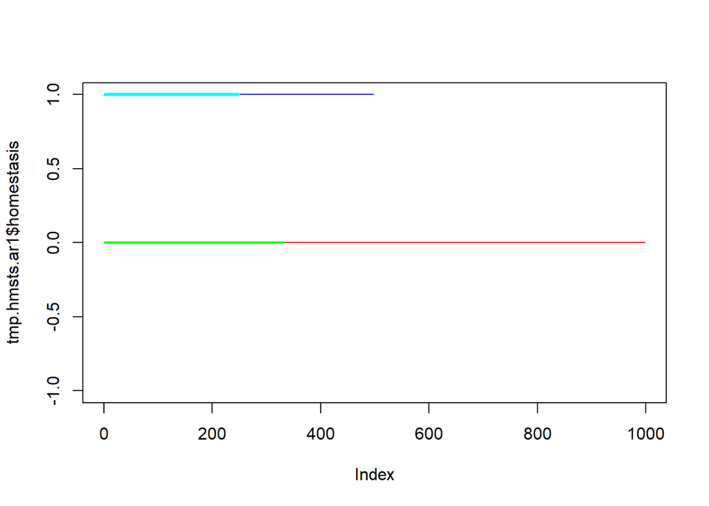

```r
plot(tmp.hmsts.ar1$homestasis, col='red', type='l')
lines(tmp.hmsts.ar2$homestasis, col='blue',lwd=1)
lines(tmp.hmsts.ar3$homestasis, col='green',lwd=2)
lines(tmp.hmsts.ar4$homestasis, col='cyan',lwd=3)
```

### 3.5.2 For more complex binary strings.

A system with n=4 variables and a cycle of period 4

|  | x1 | x2 | x3 | x4 |
| --- | --- | --- | --- | --- |
| t_1 | 1 | 1 | 0 | 0 |
| t_2 | 0 | 0 | 1 | 1 |
| t_3 | 1 | 0 | 0 | 0 |
| t_4 | 0 | 0 | 1 | 1 |
| t_5 | 1 | 1 | 0 | 0 |
| t_6 | 0 | 0 | 1 | 1 |
| t_7 | 1 | 0 | 0 | 0 |
| t_8 | 0 | 0 | 1 | 1 |
| t_9 | 1 | 1 | 0 | 0 |
| t_10 | 0 | 0 | 1 | 1 |

```r
tmp.hmsts.ar1 <- homeostasis.dataframe.autoregressive(tmp.df,b_order = 1)
tmp.hmsts.ar2 <- homeostasis.dataframe.autoregressive(tmp.df,b_order = 2)
tmp.hmsts.ar3 <- homeostasis.dataframe.autoregressive(tmp.df,b_order = 3)
tmp.hmsts.ar4 <- homeostasis.dataframe.autoregressive(tmp.df,b_order = 4)

print(paste('H(b=1):', tmp.hmsts.ar1$H_average))
```

```
## [1] "H(b=1): 0.125"
```

```r
print(paste('H(b=2):', tmp.hmsts.ar2$H_average))
```

```
## [1] "H(b=2): 0.75"
```

```r
print(paste('H(b=3):', tmp.hmsts.ar3$H_average))
```

```
## [1] "H(b=3): 0"
```

```r
print(paste('H(b=4):', tmp.hmsts.ar4$H_average))
```

```
## [1] "H(b=4): 1"
```

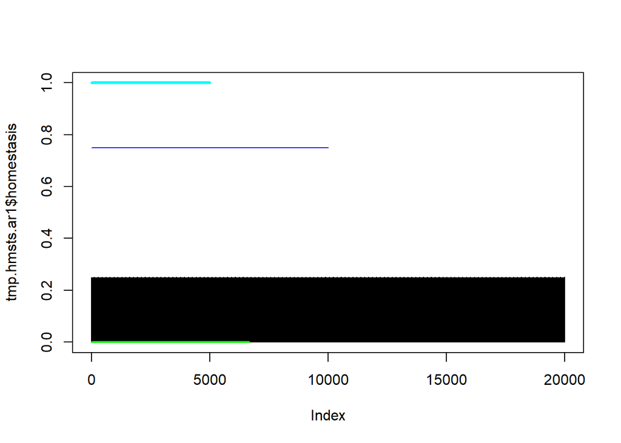

```r
plot(tmp.hmsts.ar1$homestasis, ylim = c(0,1), col='black', type='l')
lines(tmp.hmsts.ar2$homestasis, col='blue',lwd=1)
lines(tmp.hmsts.ar3$homestasis, col='green',lwd=2)
lines(tmp.hmsts.ar4$homestasis, col='cyan',lwd=3)
```

### 3.5.3 For Sine time series

In the case where variables are continuous i.e., $X_1,\ldots,X_N\in\mathbb{R}^N$, hence, a multivariate time series problem:

2. Do we need to change the base of variables measurements? e.g., going from base 10 to base 2? To do this, we would require first to discretize measurements from $\mathbb{R}\ \rightarrow\ \mathbb{Z}$ which might suppose a considerable loss of information (particularly in the case of EEG).
3. However, if we do not discretize continuous measurements, system states ($A_t=[X_1^t,\ldots,X_N^t]$ and $A_{t+1}=[X_1^{t+1},\ldots,X_N^{t+1}]$) will be trivially different by small perturbations. In the following, three different discretization methods are shown i.e., equidistant discretization, kmeans discretization, and Piecewise Aggregation Approximation (PAA). These are used to, first discretize each variable following one of the aforementioned methods. Then, $h$ and $H$ are calculated using a size of the **window of measurements**b_order = 1. If we analyze a sine time series, which of the discretization methods produces the best(more intuitive?) results?

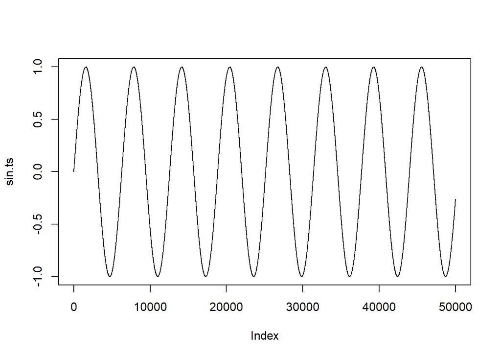

Equidistant discretization

In this method, for each variable the $x_{min}$ and $x_{max}$ values are obtained. The range defined by $[x_{min},x_{max}]$ is divided into $b$ equidistant intervals. Each interval is named using a lowercase letter, and measurements are replaced by its corresponding interval symbol.

Complexity and discretized values histogram

| E | S | C | Entrop |
| --- | --- | --- | --- |
| 0.9466463 | 0.0533537 | 0.2020283 | 3.144691 |

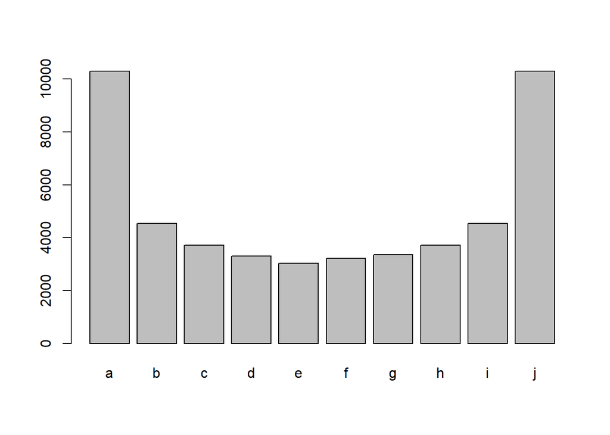

$H$ and $h$(blue) vs Sine(red) plot

```
## [1] "H= 0.99714"
```

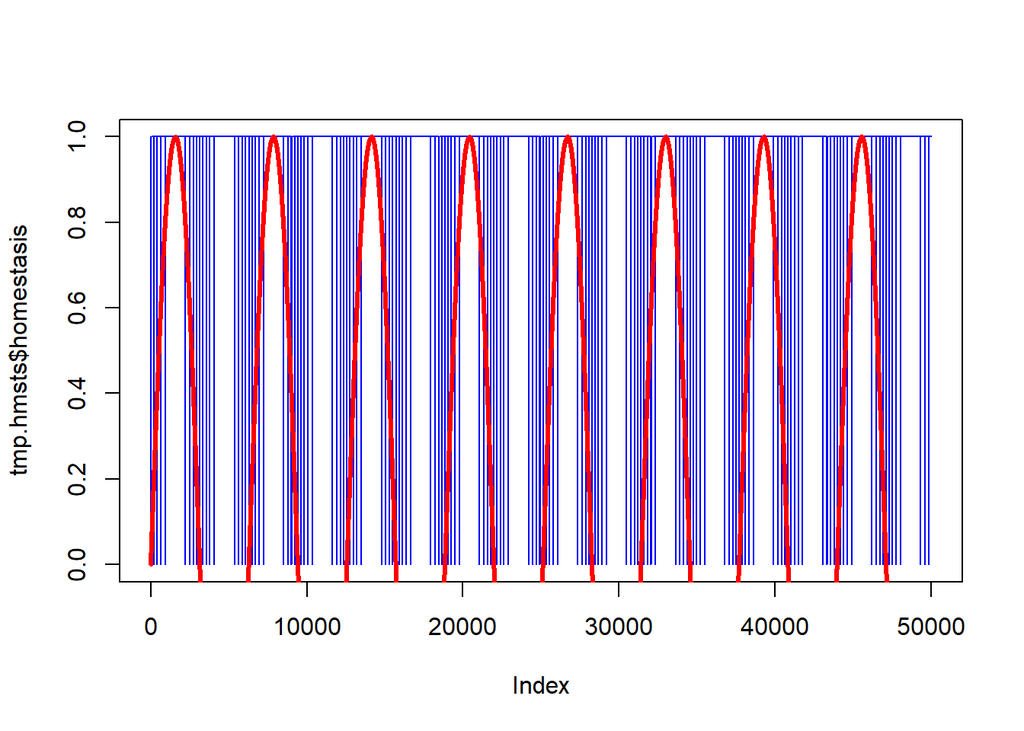

Kmeans discretization

In this method, the values for each variable are clustered using 1-D K-means. Each cluster is named using an integer, and measurements are replaced by its corresponding cluster symbol.

Complexity and discretized values histogram

| E | S | C | Entrop |
| --- | --- | --- | --- |
| 0.9745664 | 0.02543358 | 0.09914686 | 3.23744 |

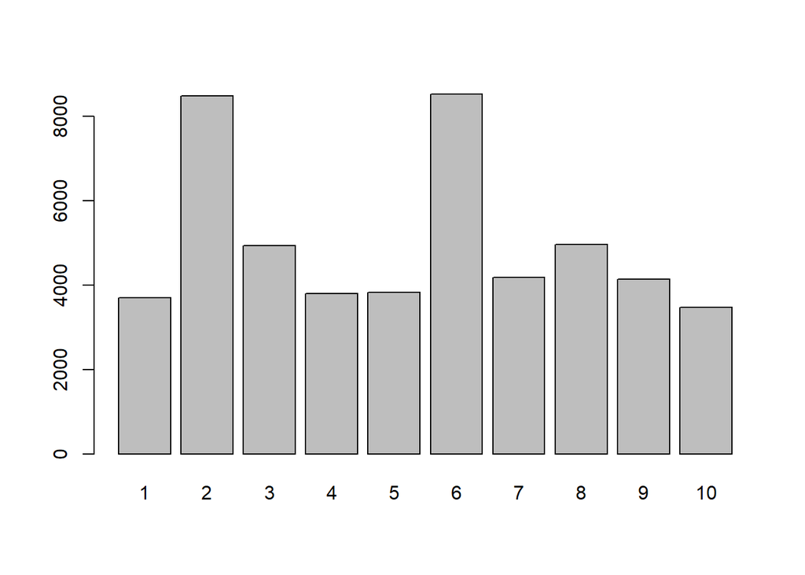

$H$ and $h$(blue) vs Sine(red) plot

```
## [1] "H= 0.99716"
```

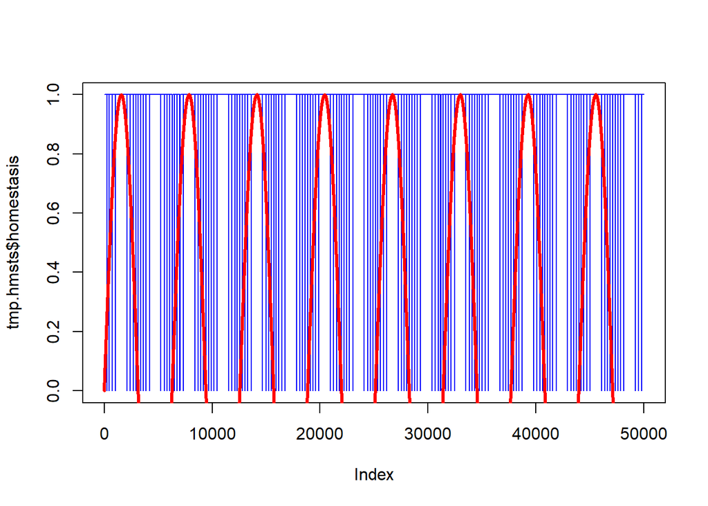

Piecewise Aggregate Approximation (PAA) discretization

PAA is an approach of average dimensional reduction, which divides the time sequence in $w$ equi-size segments, and take the mean value of each segment as representation. It requires first to *standardize* the time series. Then, the mean value of data falling within the segment will be calculated and the mean value will replace whole segment as the new representation.

Complexity and discretized values histogram

| E | S | C | Entrop |
| --- | --- | --- | --- |
| 0.8825112 | 0.1174888 | 0.4147407 | 5.863278 |

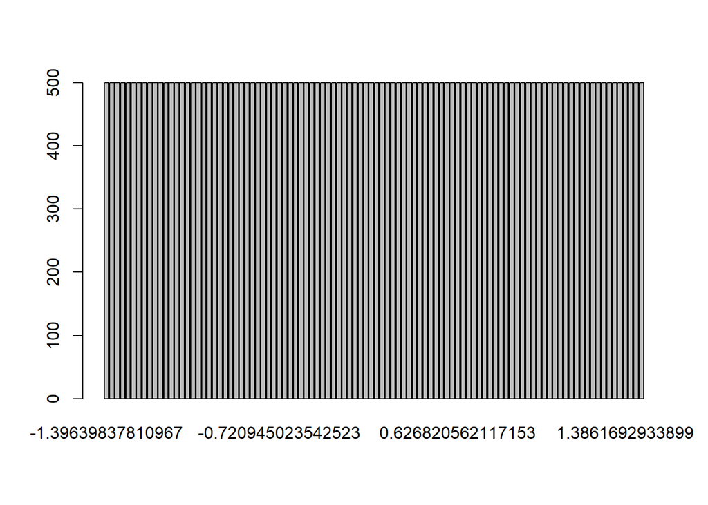

$H$ and $h$(blue) vs Sine(red) plot

```
## [1] "H= 0.998019960399208"
```

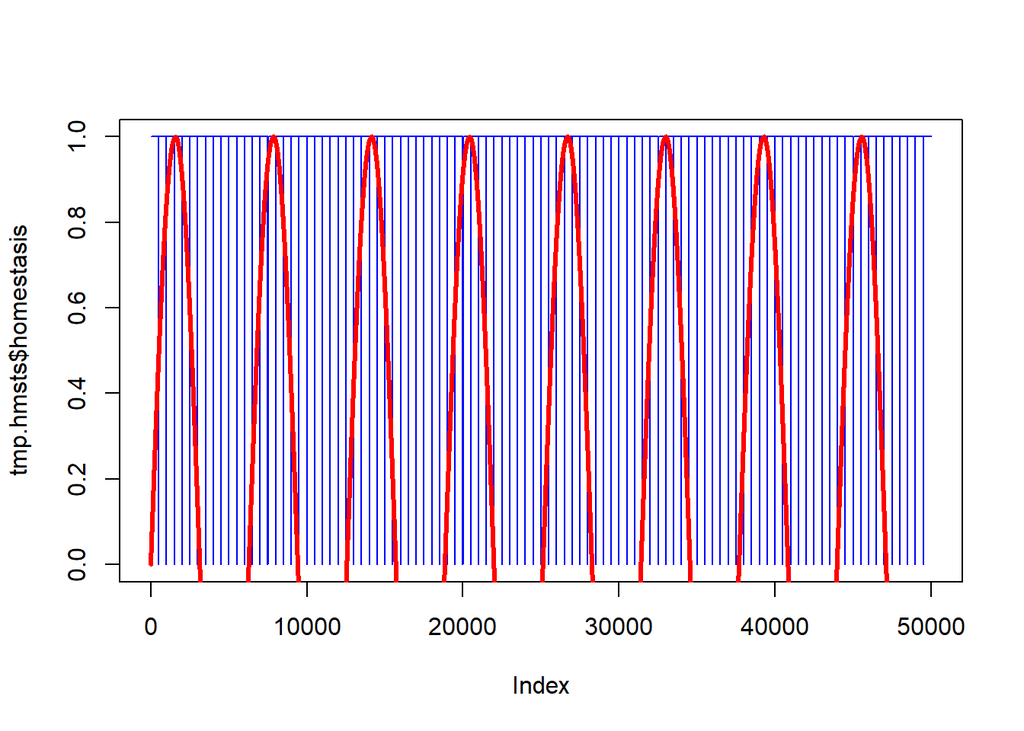

### 3.5.4 For sine + unif. noise

A sine wave contaminated by uniform noise. Results for this case shows the effect of discretization over the $H$ results. When PAA discretization is used, a high $H$ is displayed, whereas the other two discretization method displays a low $H$.

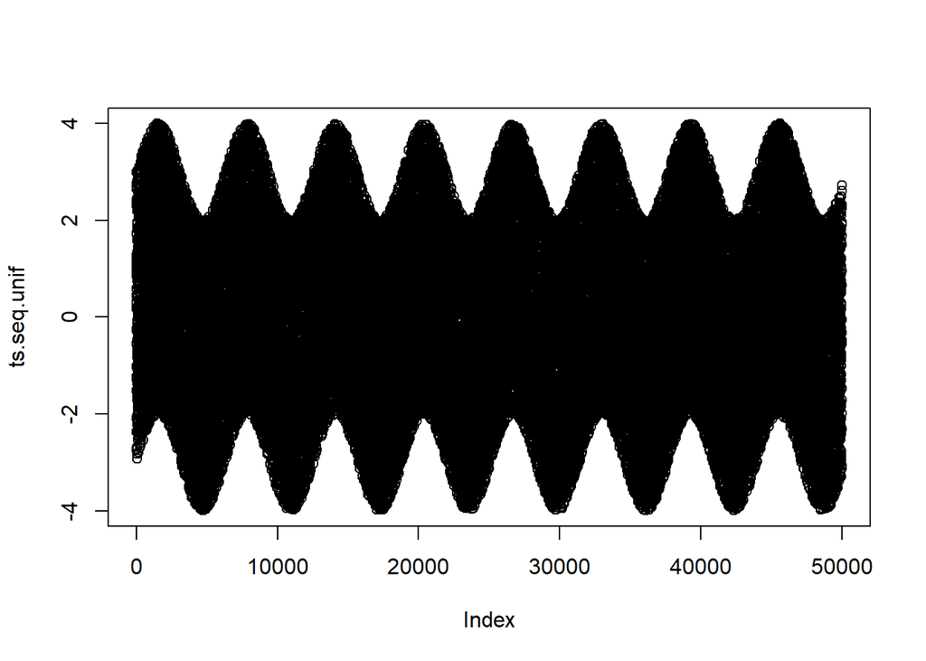

Equidistant discretization

```r
b <- 10
ts.disc <- ts.seq.unif %>% cut(breaks=b,labels=letters[1:b])
tmp.df  <- data.frame(replicate(2,ts.disc))

tmp.hmsts     <- homeostasis.dataframe(tmp_df = tmp.df)
```

Complexity and discretized values histogram

| E | S | C | Entrop |
| --- | --- | --- | --- |
| 0.9638225 | 0.03617746 | 0.1394746 | 3.201749 |

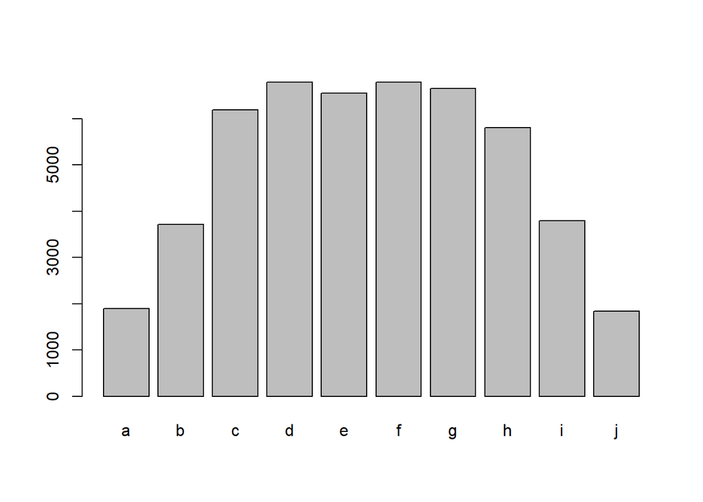

$H$ and $h$(blue) vs Sine(red) plot

```
## [1] "H= 0.12728"
```

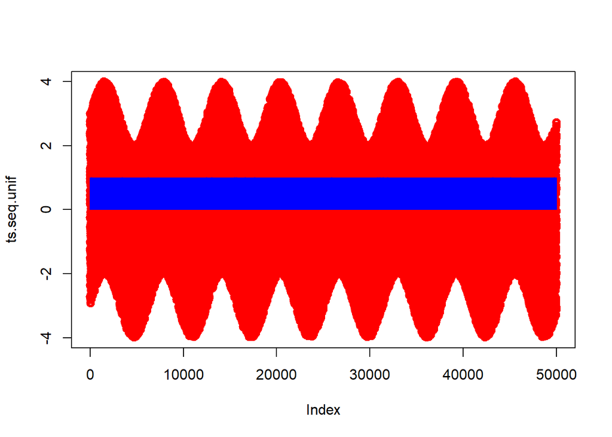

Kmeans discretization

```r
b <- 10
set.seed(123)
ts.disc<- kmeans(x = ts.seq.unif,centers = b)$cluster
tmp.df <- data.frame(replicate(2,ts.disc))

tmp.hmsts     <- homeostasis.dataframe(tmp.df)
# tmp.hmsts     <- homeostasis.dataframe.autoregressive(tmp_df = tmp.df,b_order = 1)
```

Complexity and discretized values histogram

| E | S | C | Entrop |
| --- | --- | --- | --- |
| 0.9871102 | 0.01288979 | 0.05089459 | 3.279109 |

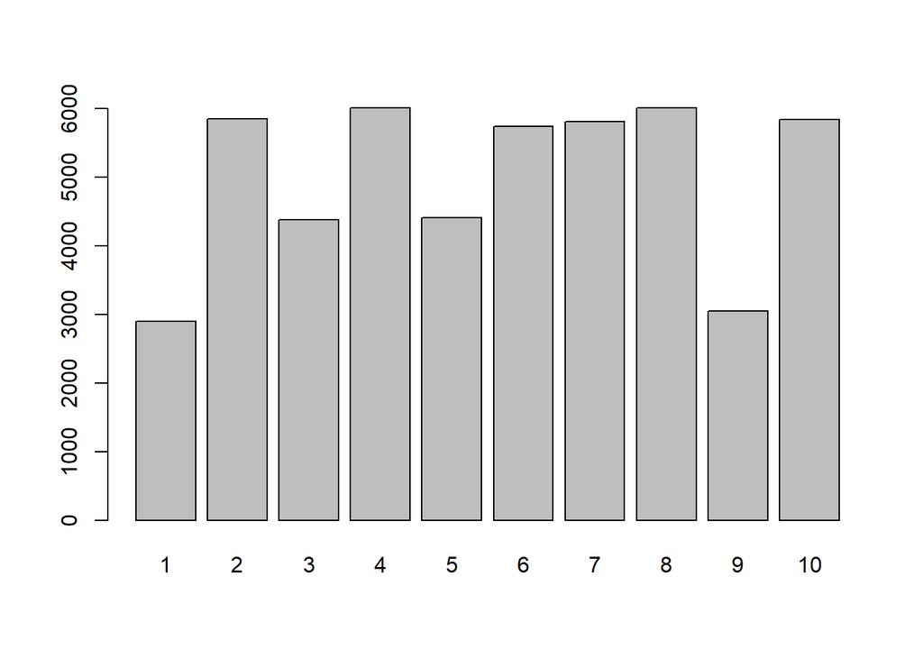

$H$ and $h$(blue) vs Sine(red) plot

```
## [1] "H= 0.12096"
```

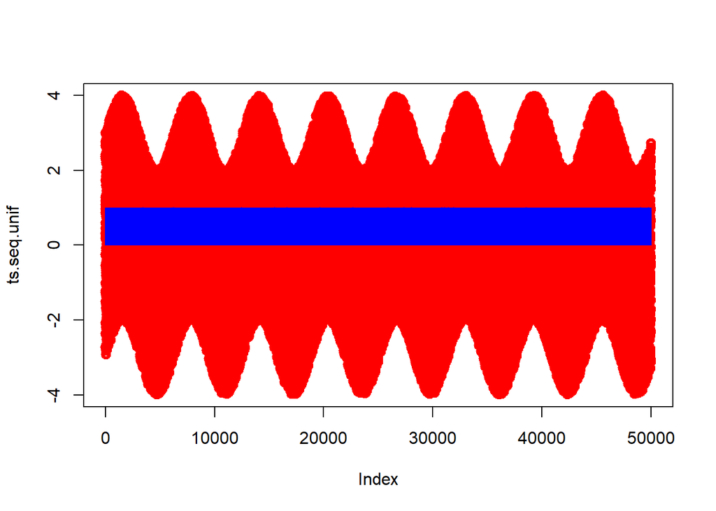

Piecewise Aggregate Approximation (PAA) discretization

```r
library(TSclust)
set.seed(12349)
w <- 100 #amount of equal-sized frames to divide the series, parameters for PAA

#normalize
y   <- (ts.seq.unif - mean(ts.seq.unif)) /sd(ts.seq.unif)

#generate PAA reductions
paay<- PAA(y, w)

ts.disc<- rep(paay,each=length(y)/length(paay))
tmp.df <- data.frame(replicate(2,ts.disc))

tmp.hmsts     <- homeostasis.dataframe(tmp.df)
# tmp.hmsts     <- homeostasis.dataframe.autoregressive(tmp_df = tmp.df,b_order = 1)
```

Complexity and discretized values histogram

| E | S | C | Entrop |
| --- | --- | --- | --- |
| 0.8756307 | 0.1243693 | 0.4356064 | 5.817564 |

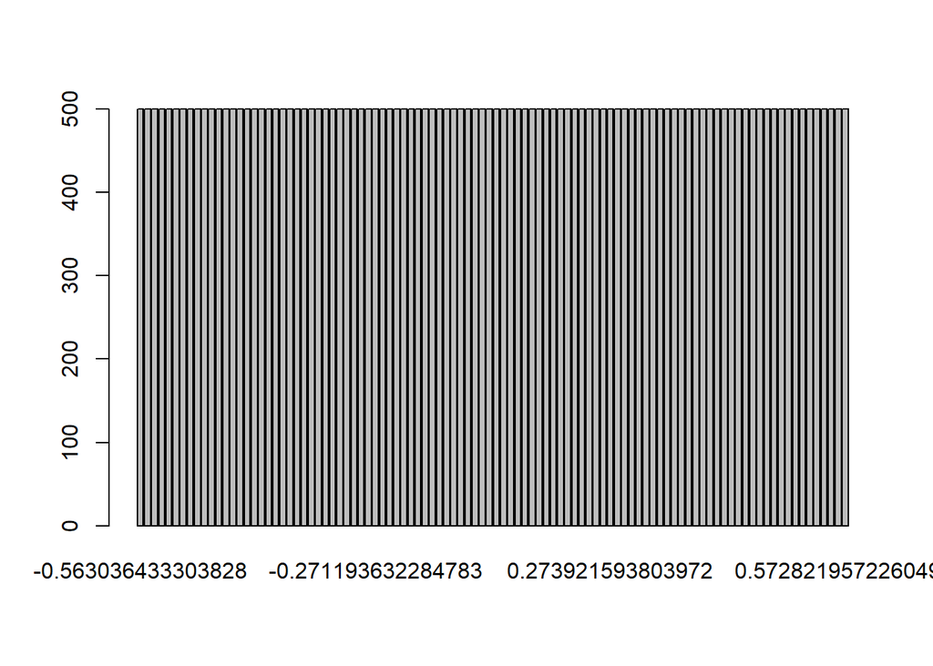

$H$ and $h$(blue) vs Sine(red) plot

```
## [1] "H= 0.998019960399208"
```

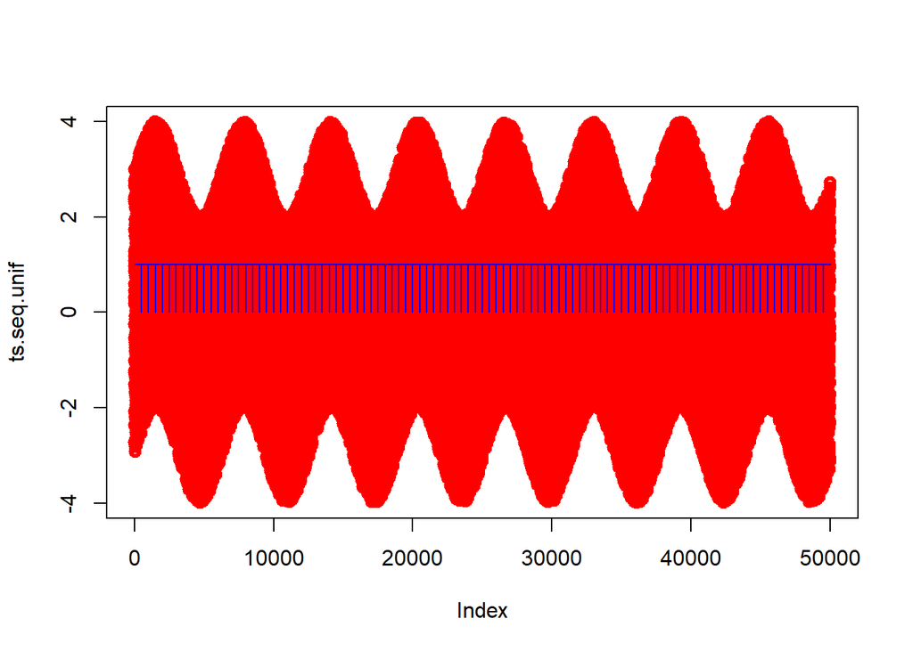

### 3.5.5 For sine + gauss noise

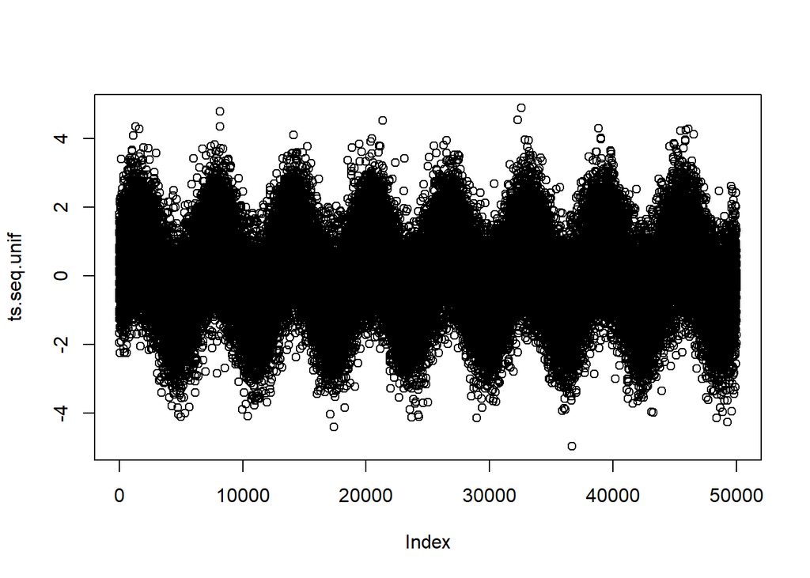

Equidistant discretization

```r
b <- 10
ts.disc <- ts.seq.unif %>% cut(breaks=b,labels=letters[1:b])
tmp.df  <- data.frame(replicate(2,ts.disc))

tmp.hmsts     <- homeostasis.dataframe(tmp.df)
```

Complexity and discretized values histogram

| E | S | C | Entrop |
| --- | --- | --- | --- |
| 0.7212956 | 0.2787044 | 0.8041131 | 2.396092 |

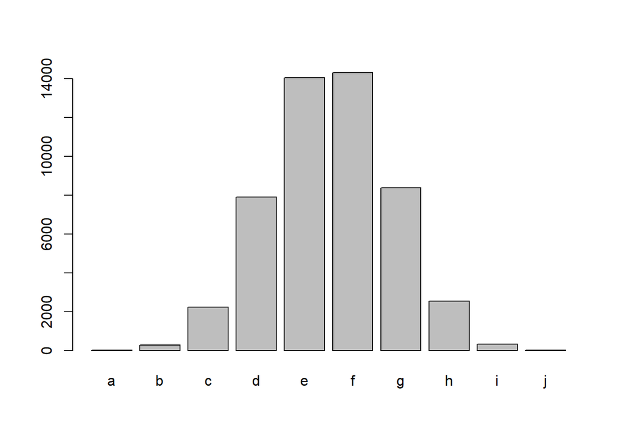

$H$ and $h$(blue) vs Sine(red) plot

```
## [1] "H= 0.26816"
```

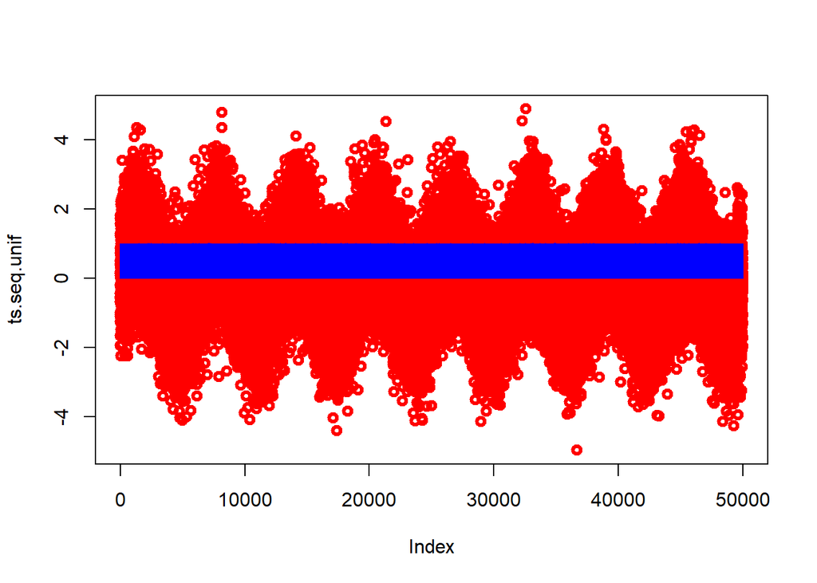

Kmeans discretization

```r
b <- 10
set.seed(123)
ts.disc<- kmeans(x = ts.seq.unif,centers = b)$cluster
tmp.df <- data.frame(replicate(2,ts.disc))

tmp.hmsts     <- homeostasis.dataframe(tmp.df)
```

Complexity and discretized values histogram

| E | S | C | Entrop |
| --- | --- | --- | --- |
| 0.9464616 | 0.05353842 | 0.2026882 | 3.144077 |

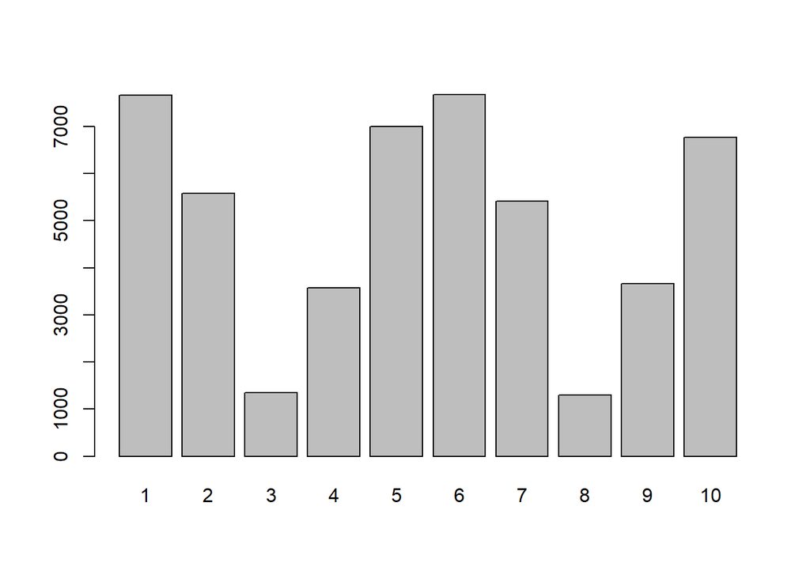

$H$ and $h$(blue) vs Sine(red) plot

```
## [1] "H= 0.15228"
```

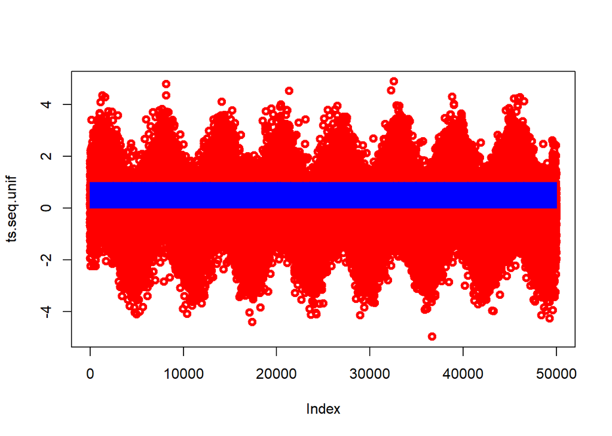

Piecewise Aggregate Approximation (PAA) discretization

```r
library(TSclust)
set.seed(12349)
w <- 1000 #amount of equal-sized frames to divide the series, parameters for PAA

#normalize
y   <- (ts.seq.unif - mean(ts.seq.unif)) /sd(ts.seq.unif)

#generate PAA reductions
paay<- PAA(y, w)

ts.disc<- rep(paay,each=length(y)/length(paay))
tmp.df <- data.frame(replicate(2,ts.disc))

# tmp.hmsts     <- homeostasis.dataframe(tmp.df)
tmp.hmsts     <- homeostasis.dataframe.autoregressive(tmp_df = tmp.df,b_order = 1)
```

Complexity and discretized values histogram

| E | S | C | Entrop |
| --- | --- | --- | --- |
| 0.9056397 | 0.09436029 | 0.3418257 | 9.02541 |

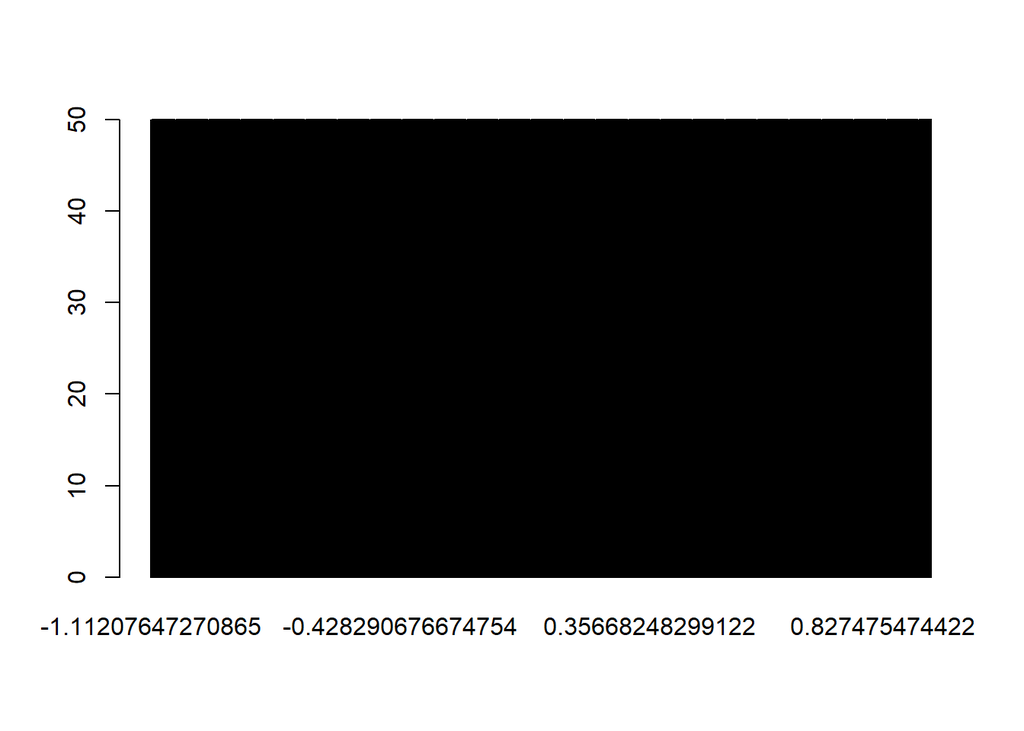

$H$ and $h$(blue) vs Sine(red) plot

```
## [1] "H= 0.980019200768031"
```

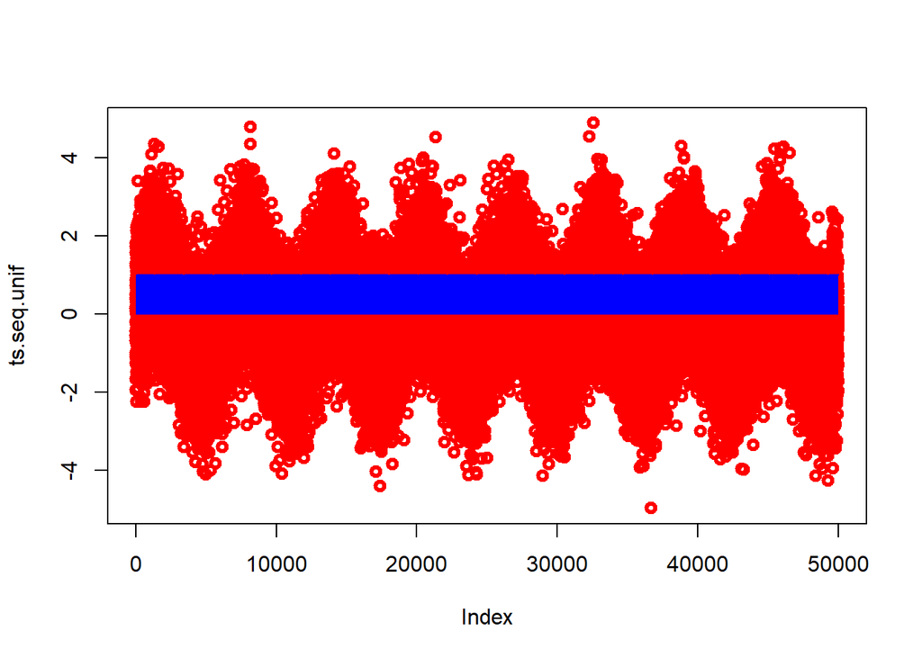

### 3.5.6 Final thoughts

One can say that H is used to understand if a system dynamics maintain close to a certain state or states (attractors) (Fernández, Maldonado, and Gershenson 2014). Thus, H can be used as other linear and non-linear tools to study dynamical systems, and even chaotic behaviors (strange attractors). Thus, a Time-delay embedding model could be employed to compare between system states.

# 4 References

Fernández, N, C Maldonado, and C Gershenson. 2014. “Information Measures of Complexity, Emergence, Self-organization, Homeostasis, and Autopoiesis.” In *Guided Self-Organization: Inception*, edited by Mikhail Prokopenko, 9:19–51. Emergence, Complexity and Computation. Berlin Heidelberg: Springer. https://doi.org/10.1007/978-3-642-53734-9_2.

Gershenson, Carlos, and Nelson Fernández. 2012. “Complexity and information: Measuring emergence, self-organization, and homeostasis at multiple scales.” *Complexity* 18 (2): 29–44. https://doi.org/10.1002/cplx.21424.